# Modelos Logisticos Binarios e Multinomiais

# Regressão Binária

É uma distribuição de probabilidade de ocorrência de determinado evento (Binominal). Os valores podem estar entre Não-Evento(0) e Evento(1).

## Importando bibliotecas e dados

```python
import pandas as pd                     # manipulação de dado em formato de dataframe
import seaborn as sns                   # biblioteca de visualização de informações estatísticas
import matplotlib.pyplot as plt         # biblioteca de visualização de dados
import statsmodels.api as sm            # biblioteca de modelagem estatística
import numpy as np                      # biblioteca para operações matemáticas multidimensionais
import statsmodels.formula.api as smf   # biblioteca para modelagem glm
import scipy.stats as st
import tabulate
from scipy import stats
from statsmodels.iolib.summary2 import summary_col
from sklearn.metrics import confusion_matrix, accuracy_score, ConfusionMatrixDisplay, recall_score,roc_curve,auc
from statsmodels.discrete.discrete_model import MNLogit



dados = pd.read_csv("atrasado.csv")
```

## Análise Exploratória

#### Visualizar os Dados

A base dados conta com observações de alunos que chegaram atrasados a aula, informando a distância(km) percorrida e a quantidade de semáforos pegos durante o trajeto.

#### Características das variáveis

```python
dados.info()
```

```
<class 'pandas.core.frame.DataFrame'>
RangeIndex: 100 entries, 0 to 99
Data columns (total 4 columns):
 #   Column     Non-Null Count  Dtype
---  ------     --------------  -----
 0   estudante  100 non-null    object
 1   atrasado   100 non-null    int64
 2   dist       100 non-null    float64
 3   sem        100 non-null    int64
dtypes: float64(1), int64(2), object(1)
memory usage: 3.2+ KB
```

#### Estatísticas univariadas

```python
dados.describe()
```

|  | atrasado | dist | sem |
| --- | --- | --- | --- |
| count | 100.000000 | 100.000000 | 100.000000 |
| mean | 0.590000 | 14.073000 | 10.210000 |
| std | 0.494311 | 4.330112 | 1.578229 |
| min | 0.000000 | 1.000000 | 5.000000 |
| 25% | 0.000000 | 12.000000 | 10.000000 |
| 50% | 1.000000 | 13.350000 | 10.000000 |
| 75% | 1.000000 | 16.125000 | 10.000000 |
| max | 1.000000 | 29.000000 | 18.000000 |

#### Contagem dos Valores

```python
print('0 = não atrasado')
print('1 = atrasado')
dados['atrasado'].value_counts()
```

```
0 = não atrasado
1 = atrasado
```

```
atrasado
1    59
0    41
Name: count, dtype: int64
```

## Estimação de um modelo logístico binário

```python
modelo = smf.glm(formula = 'atrasado ~ dist + sem',
                                        data=dados,
                                        family= sm.families.Binomial()).fit()
```

### Parâmetros do modelo

```python
modelo.summary()
```

Generalized Linear Model Regression Results

| Dep. Variable: | atrasado | No. Observations: | 100 |
| --- | --- | --- | --- |
| Model: | GLM | Df Residuals: | 97 |
| Model Family: | Binomial | Df Model: | 2 |
| Link Function: | Logit | Scale: | 1.0000 |
| Method: | IRLS | Log-Likelihood: | -50.466 |
| Date: | Tue, 09 Apr 2024 | Deviance: | 100.93 |
| Time: | 14:23:36 | Pearson chi2: | 86.7 |
| No. Iterations: | 7 | Pseudo R-squ. (CS): | 0.2913 |
| Covariance Type: | nonrobust |  |  |

|  | coef | std err | z | P>\|z\| | [0.025 | 0.975] |
| --- | --- | --- | --- | --- | --- | --- |
| Intercept | -26.1665 | 8.442 | -3.100 | 0.002 | -42.712 | -9.621 |
| dist | 0.1904 | 0.076 | 2.493 | 0.013 | 0.041 | 0.340 |
| sem | 2.3629 | 0.795 | 2.972 | 0.003 | 0.804 | 3.921 |

As informações geradas pelo modelo, que servem de métricas para analisar os paramêtros e a eficiência global do modelo. As mais relevantes para analisar o modelo são o P-valor de cada variável pretidora, e Log-Likelihood do modelo. O P-valor (P>|Z|) obtido para cada variável ficou abaixo do de 0.05 ou 5%, isto mostra que os dois Betas são estatisticamente significantes para a contrusção do modelo. O Log-Liklihood quanto mais alto melhor, ele é um parâmetro de comparação entre dois modelos. O Qui-quadrado(Pearson Chi2) mostra a correlação entre as variáveis.

### Adicionando as predições inteiras e seus percentuais de probabilidade na base de dados

```python
dados['resultado'] = modelo.predict()
dados['resultado(%)'] = modelo.predict()*100
dados
```

|  | estudante | atrasado | dist | sem | resultado | resultado(%) |
| --- | --- | --- | --- | --- | --- | --- |
| 0 | Gabriela | 0 | 12.5 | 7 | 0.000712 | 0.071202 |
| 1 | Patricia | 0 | 13.3 | 10 | 0.498561 | 49.856131 |
| 2 | Gustavo | 0 | 13.4 | 8 | 0.008903 | 0.890254 |
| 3 | Leticia | 0 | 23.5 | 7 | 0.005751 | 0.575127 |
| 4 | Luiz Ovidio | 0 | 9.5 | 8 | 0.004257 | 0.425694 |
| ... | ... | ... | ... | ... | ... | ... |
| 95 | Sheila | 1 | 24.0 | 10 | 0.884040 | 88.404017 |
| 96 | Pedro | 1 | 10.0 | 10 | 0.346606 | 34.660579 |
| 97 | Horacio | 1 | 9.4 | 10 | 0.321210 | 32.120980 |
| 98 | Leandro | 1 | 14.2 | 10 | 0.541301 | 54.130138 |
| 99 | Estela | 1 | 1.0 | 13 | 0.991348 | 99.134795 |

100 rows × 6 columns

Agora cada observação conta com a presença da coluna de resultado, que foi predito utilizando o modelo desenvovlido. Assim pode se ver a probabilidade de ocorrência para cada observação.

## Métricas para análise do modelo

Ao realizar uma Regressão Binária, é fundamental determinar um valor de cutt-off que irá considerar uma faixa para as probabilidades preditas serem eventos ou não-eventos. Os valores podem assumir números entre 0 e 1.

#### Construção de Função para matriz de confusão para determinado Cutoff

```python
def matriz_confusao(observado,predicts,cutoff):

    values = predicts.values

    predicao_binaria = []

    for item in values:
        if item >= cutoff:
            predicao_binaria.append(1)
        else:
            predicao_binaria.append(0)

    cm = confusion_matrix(observado, predicao_binaria)
    disp = ConfusionMatrixDisplay(confusion_matrix=cm)
    disp.plot()
    plt.show()

    sensitividade = recall_score(observado, predicao_binaria, pos_label=1)
    especificidadee = recall_score(observado, predicao_binaria, pos_label=0)
    acuracia = accuracy_score(observado, predicao_binaria)

    #Visualizando os principais indicadores desta matriz de confusão
    indicadores = pd.DataFrame({'Sensitividade':[sensitividade],
                                'Especificidade':[especificidadee],
                                'Acurácia':[acuracia]})
    indicadores = indicadores.to_markdown()
    return indicadores
```

#### Rodando Função de matriz de Confusão para Cuttof = 0.5

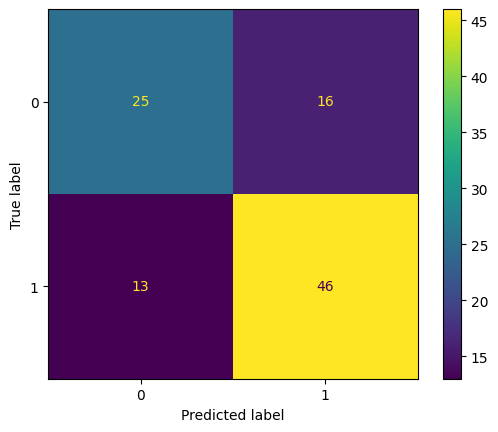

[output not shown]

```python
matriz_confusao(observado=dados['atrasado'],
                predicts=dados['resultado'],
                cutoff=0.5)
```

### Função para testar cutoffs entre 0,1 até 1.01

```python
def espec_sens(observado,predicts):

    # adicionar objeto com os valores dos predicts
    values = predicts.values

    # range dos cutoffs a serem analisados em steps de 0.01
    cutoffs = np.arange(0,1.01,0.01)

    # Listas que receberão os resultados de especificidade e sensitividade
    lista_sensitividade = []
    lista_especificidade = []

    for cutoff in cutoffs:

        predicao_binaria = []

        # Definindo resultado binário de acordo com o predict
        for item in values:
            if item >= cutoff:
                predicao_binaria.append(1)
            else:
                predicao_binaria.append(0)

        # Cálculo da sensitividade e especificidade no cutoff
        sensitividade = recall_score(observado, predicao_binaria, pos_label=1)
        especificidadee = recall_score(observado, predicao_binaria, pos_label=0)

        # Adicionar valores nas listas
        lista_sensitividade.append(sensitividade)
        lista_especificidade.append(especificidadee)

    # Criar dataframe com os resultados nos seus respectivos cutoffs
    resultado = pd.DataFrame({'cutoffs':cutoffs,'sensitividade':lista_sensitividade,'especificidade':lista_especificidade})
    return resultado
```

### Rodando Função nos Dados

```python
dados_plotagem = espec_sens(observado = dados['atrasado'],
                            predicts = dados['resultado'])
dados_plotagem
```

|  | cutoffs | sensitividade | especificidade |
| --- | --- | --- | --- |
| 0 | 0.00 | 1.000000 | 0.000000 |
| 1 | 0.01 | 1.000000 | 0.170732 |
| 2 | 0.02 | 1.000000 | 0.170732 |
| 3 | 0.03 | 1.000000 | 0.170732 |
| 4 | 0.04 | 1.000000 | 0.170732 |
| ... | ... | ... | ... |
| 96 | 0.96 | 0.135593 | 1.000000 |
| 97 | 0.97 | 0.135593 | 1.000000 |
| 98 | 0.98 | 0.135593 | 1.000000 |
| 99 | 0.99 | 0.101695 | 1.000000 |
| 100 | 1.00 | 0.000000 | 1.000000 |

101 rows × 3 columns

### Plotando Gráfico Sensitividade/Especificidade em função do Cuttof

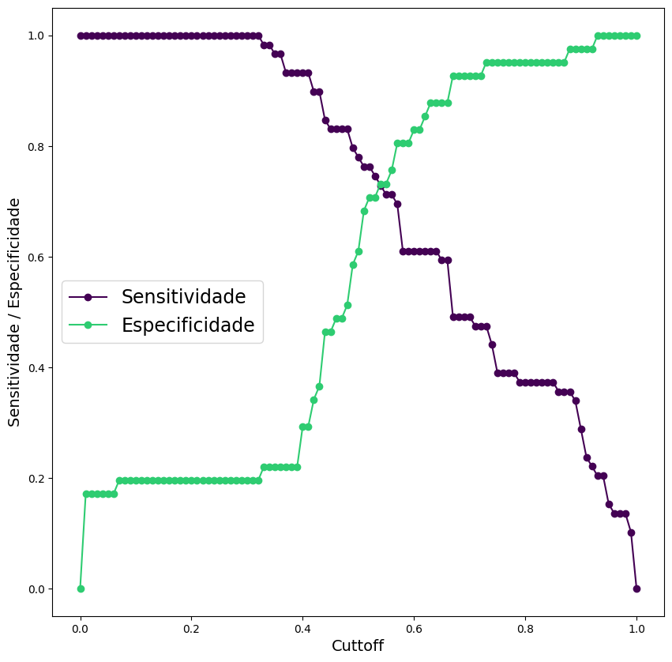

```python
plt.figure(figsize=(10,10))
plt.plot(dados_plotagem.cutoffs,dados_plotagem.sensitividade, '-o',
         color="#440154FF")
plt.plot(dados_plotagem.cutoffs,dados_plotagem.especificidade, '-o',
         color="#2ecc71")
plt.legend(['Sensitividade', 'Especificidade'], fontsize=17)
plt.xlabel("Cuttoff", fontsize=14)
plt.ylabel("Sensitividade / Especificidade", fontsize=14)
plt.show()
```

Esse grafico mostra as taxas de especifidade/ sensitividade variando em função do cutt-off.

### Plotagem Curva ROC

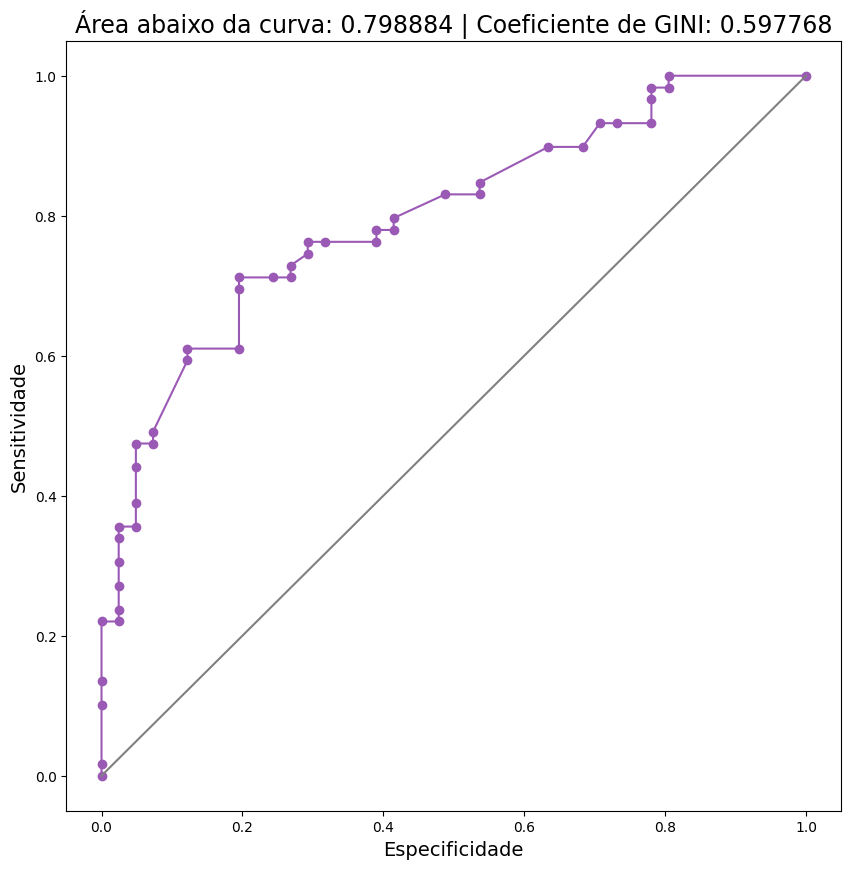

```python
fpr, tpr, thresholds = roc_curve(dados['atrasado'],dados['resultado'])
roc_auc = auc(fpr, tpr)

#Cálculo do coeficiente de GINI
gini = (roc_auc - 0.5)/(0.5)

#Plotando a curva ROC
plt.figure(figsize=(10,10))
plt.plot(fpr,tpr, '-o', color="#9b59b6")
plt.plot(fpr,fpr, color='gray')
plt.title("Área abaixo da curva: %f" % roc_auc +
          " | Coeficiente de GINI: %f" % gini, fontsize=17)
plt.xlabel("Especificidade", fontsize=14)
plt.ylabel("Sensitividade", fontsize=14)
plt.show()
```

A curva roc é um dos parâmetros que mais informa a qualidade global do modelo. a curva roc é uma curva da especifidade em função da sensitividade, criando uma área de acerto que mostra demonstra a eficiência do modelo. Quanto maior a área, melhor o ajuste do modelo.

# Regressão Multinomial

É uma distribuição de probabilidade de ocorrência de multiplos eventos. Os valores podem estar entre referência(0), Evento-1(1), Evento-2(2), Evento-x(x). É calculado a probabilidade de ocorrência de cada evento possível para determinada observação.

## Importando bibliotecas e dados

```python
import pandas as pd                     # manipulação de dado em formato de dataframe
import seaborn as sns                   # biblioteca de visualização de informações estatísticas
import matplotlib.pyplot as plt         # biblioteca de visualização de dados
import statsmodels.api as sm            # biblioteca de modelagem estatística
import numpy as np                      # biblioteca para operações matemáticas multidimensionais
import statsmodels.formula.api as smf   # biblioteca para modelagem glm
import scipy.stats as st
from statsmodels.iolib.summary2 import summary_col
from sklearn.metrics import confusion_matrix, accuracy_score, ConfusionMatrixDisplay, recall_score,roc_curve,auc
from statsmodels.discrete.discrete_model import MNLogit


dados_multinomial = pd.read_csv("atrasado_multinomial.csv",
                   delimiter = ',')
```

## Análise Exploratória

### Visualização dos dados

```python
dados_multinomial
```

|  | estudante | atrasado | dist | sem |
| --- | --- | --- | --- | --- |
| 0 | Gabriela | chegou atrasado segunda aula | 20.500000 | 15 |
| 1 | Patricia | chegou atrasado segunda aula | 21.299999 | 18 |
| 2 | Gustavo | chegou atrasado segunda aula | 21.400000 | 16 |
| 3 | Leticia | chegou atrasado segunda aula | 31.500000 | 15 |
| 4 | Luiz Ovidio | chegou atrasado segunda aula | 17.500000 | 16 |
| ... | ... | ... | ... | ... |
| 95 | Sheila | nao chegou atrasado | 24.000000 | 10 |
| 96 | Pedro | chegou atrasado primeira aula | 15.000000 | 15 |
| 97 | Horacio | chegou atrasado primeira aula | 14.400000 | 15 |
| 98 | Leandro | chegou atrasado segunda aula | 22.200001 | 18 |
| 99 | Estela | nao chegou atrasado | 1.000000 | 13 |

100 rows × 4 columns

A base dados conta com observações de alunos que chegaram atrasados para primeira aula, ou atrasados para segunda aula ou os que não chegaram atrasados, informando a distância(km) percorrida e a quantidade de semáforos pegos durante o trajeto.

### Características das variáveis

```python
dados_multinomial.info()
```

```
<class 'pandas.core.frame.DataFrame'>
RangeIndex: 100 entries, 0 to 99
Data columns (total 4 columns):
 #   Column     Non-Null Count  Dtype
---  ------     --------------  -----
 0   estudante  100 non-null    object
 1   atrasado   100 non-null    object
 2   dist       100 non-null    float64
 3   sem        100 non-null    int64
dtypes: float64(1), int64(1), object(2)
memory usage: 3.2+ KB
```

### Estatísticas das variáveis

```python
dados_multinomial.describe()
```

|  | dist | sem |
| --- | --- | --- |
| count | 100.000000 | 100.000000 |
| mean | 17.673000 | 13.810000 |
| std | 5.130299 | 3.329376 |
| min | 1.000000 | 10.000000 |
| 25% | 14.950000 | 10.000000 |
| 50% | 18.750000 | 15.000000 |
| 75% | 21.000000 | 18.000000 |
| max | 31.500000 | 19.000000 |

### Contagem dos valores

```python
dados_multinomial['atrasado'].value_counts(sort=False)
```

```
atrasado
chegou atrasado segunda aula     35
chegou atrasado primeira aula    16
nao chegou atrasado              49
Name: count, dtype: int64
```

## Estimação do Modelo

### Criando Categorias de Referencia

```python
dados_multinomial.loc[dados_multinomial['atrasado']==
                            'nao chegou atrasado',
                            'atrasado2'] = 0 #categoria de referência
dados_multinomial.loc[dados_multinomial['atrasado']==
                            'chegou atrasado primeira aula',
                            'atrasado2'] = 1
dados_multinomial.loc[dados_multinomial['atrasado']==
                            'chegou atrasado segunda aula',
                            'atrasado2'] = 2
```

É necessário definir um evento como referência antes de estimar o modelo. E também criar valores para cada evento possivel, assim será possivel estimar o modelo corretamente. Foi definido que nao chegou atrasado = 0 chegou atrasado primeira aula = 1 chegou atrasado segunda aula = 2

```python
dados_multinomial
```

|  | estudante | atrasado | dist | sem | atrasado2 |
| --- | --- | --- | --- | --- | --- |
| 0 | Gabriela | chegou atrasado segunda aula | 20.500000 | 15 | 2.0 |
| 1 | Patricia | chegou atrasado segunda aula | 21.299999 | 18 | 2.0 |
| 2 | Gustavo | chegou atrasado segunda aula | 21.400000 | 16 | 2.0 |
| 3 | Leticia | chegou atrasado segunda aula | 31.500000 | 15 | 2.0 |
| 4 | Luiz Ovidio | chegou atrasado segunda aula | 17.500000 | 16 | 2.0 |
| ... | ... | ... | ... | ... | ... |
| 95 | Sheila | nao chegou atrasado | 24.000000 | 10 | 0.0 |
| 96 | Pedro | chegou atrasado primeira aula | 15.000000 | 15 | 1.0 |
| 97 | Horacio | chegou atrasado primeira aula | 14.400000 | 15 | 1.0 |
| 98 | Leandro | chegou atrasado segunda aula | 22.200001 | 18 | 2.0 |
| 99 | Estela | nao chegou atrasado | 1.000000 | 13 | 0.0 |

100 rows × 5 columns

### Estimação do Modelo

```python
x = dados_multinomial.drop(columns=['estudante','atrasado','atrasado2'])
y = dados_multinomial['atrasado2']
X = sm.add_constant(x)
modelo_atrasado = MNLogit(endog=y, exog=X).fit()
```

```
Optimization terminated successfully.
         Current function value: 0.245118
         Iterations 10
```

Estimação do modelo Atrasado2 ~ Distancia e Semaforos

### Parâmetros do modelo

```python
modelo_atrasado.summary()
```

MNLogit Regression Results

| Dep. Variable: | atrasado2 | No. Observations: | 100 |
| --- | --- | --- | --- |
| Model: | MNLogit | Df Residuals: | 94 |
| Method: | MLE | Df Model: | 4 |
| Date: | Fri, 05 Apr 2024 | Pseudo R-squ.: | 0.7574 |
| Time: | 16:10:13 | Log-Likelihood: | -24.512 |
| converged: | True | LL-Null: | -101.02 |
| Covariance Type: | nonrobust | LLR p-value: | 4.598e-32 |

| atrasado2=1 | coef | std err | z | P>\|z\| | [0.025 | 0.975] |
| --- | --- | --- | --- | --- | --- | --- |
| const | -33.1352 | 12.183 | -2.720 | 0.007 | -57.014 | -9.256 |
| dist | 0.5588 | 0.243 | 2.297 | 0.022 | 0.082 | 1.036 |
| sem | 1.6699 | 0.577 | 2.895 | 0.004 | 0.539 | 2.801 |
| atrasado2=2 | coef | std err | z | P>\|z\| | [0.025 | 0.975] |
| const | -62.2922 | 14.675 | -4.245 | 0.000 | -91.055 | -33.530 |
| dist | 1.0784 | 0.302 | 3.566 | 0.000 | 0.486 | 1.671 |
| sem | 2.8949 | 0.686 | 4.220 | 0.000 | 1.550 | 4.239 |

Podemos interpertrar da mesma forma que o modelo binário. Só que agora temos duas equações para se analisar, ja que temos 2 possiveis eventos. As mais relevantes para analisar o modelo são o P-valor de cada variável pretidora, e Log-Likelihood do modelo Equação para o evento 1 e equação para evento 2.

### Qui²

```python
def Qui2(modelo_multinomial):
    maximo = modelo_multinomial.llf
    minimo = modelo_multinomial.llnull
    qui2 = -2*(minimo - maximo)
    pvalue = stats.distributions.chi2.sf(qui2,1)
    df = pd.DataFrame({'Qui quadrado':[qui2],
                       'pvalue':[pvalue]})
    return df
Qui2(modelo_atrasado)
```

|  | Qui quadrado | pvalue |
| --- | --- | --- |
| 0 | 153.014842 | 3.802150e-35 |

## Predições

### Realizando Predição e adicionando ao banco de dados (Probabilidades)

```python
resultado = modelo_atrasado.predict()
resultado = pd.DataFrame(resultado)
dados_multinomial = pd.concat([dados_multinomial, resultado], axis=1)
```

### Adicionando maior probabilidade da predição

```python
classificacao = resultado.idxmax(axis=1)
dados_multinomial['predicao'] = classificacao
dados_multinomial
```

|  | estudante | atrasado | dist | sem | atrasado2 | 0 | 1 | 2 | predicao |
| --- | --- | --- | --- | --- | --- | --- | --- | --- | --- |
| 0 | Gabriela | chegou atrasado segunda aula | 20.500000 | 15 | 2.0 | 1.801024e-02 | 0.523388 | 4.586018e-01 | 1 |
| 1 | Patricia | chegou atrasado segunda aula | 21.299999 | 18 | 2.0 | 2.751301e-06 | 0.018737 | 9.812605e-01 | 2 |
| 2 | Gustavo | chegou atrasado segunda aula | 21.400000 | 16 | 2.0 | 6.796190e-04 | 0.173472 | 8.258489e-01 | 2 |
| 3 | Leticia | chegou atrasado segunda aula | 31.500000 | 15 | 2.0 | 2.759476e-07 | 0.003748 | 9.962518e-01 | 2 |
| 4 | Luiz Ovidio | chegou atrasado segunda aula | 17.500000 | 16 | 2.0 | 2.083782e-02 | 0.601588 | 3.775739e-01 | 1 |
| ... | ... | ... | ... | ... | ... | ... | ... | ... | ... |
| 95 | Sheila | nao chegou atrasado | 24.000000 | 10 | 0.0 | 9.531361e-01 | 0.046317 | 5.471598e-04 | 0 |
| 96 | Pedro | chegou atrasado primeira aula | 15.000000 | 15 | 1.0 | 4.146183e-01 | 0.557343 | 2.803830e-02 | 1 |
| 97 | Horacio | chegou atrasado primeira aula | 14.400000 | 15 | 1.0 | 5.008256e-01 | 0.481441 | 1.773339e-02 | 0 |
| 98 | Leandro | chegou atrasado segunda aula | 22.200001 | 18 | 2.0 | 1.049763e-06 | 0.011822 | 9.881774e-01 | 2 |
| 99 | Estela | nao chegou atrasado | 1.000000 | 13 | 0.0 | 9.999809e-01 | 0.000019 | 5.741634e-11 | 0 |

100 rows × 9 columns

Agora cada observação conta com a presença das colunas 0,1 e 2, que mostram a probabilidade para cada evento. E também com a coluna 'predição' que mostra o evento com maior probabilidade de ocorrência.

### Criando Variavel "Predição" que rotula o evento com maior probabilidade

```python
dados_multinomial.loc[dados_multinomial['predicao']==0,
                            'predicao_label'] ='nao chegou atrasado'
dados_multinomial.loc[dados_multinomial['predicao']==1,
                            'predicao_label'] ='chegou atrasado primeira aula'
dados_multinomial.loc[dados_multinomial['predicao']==2,
                            'predicao_label'] ='chegou atrasado segunda aula'
```

### Visualizando Predições Rotuladas

```python
dados_multinomial
```

|  | estudante | atrasado | dist | sem | atrasado2 | 0 | 1 | 2 | predicao | predicao_label |
| --- | --- | --- | --- | --- | --- | --- | --- | --- | --- | --- |
| 0 | Gabriela | chegou atrasado segunda aula | 20.500000 | 15 | 2.0 | 1.801024e-02 | 0.523388 | 4.586018e-01 | 1 | chegou atrasado primeira aula |
| 1 | Patricia | chegou atrasado segunda aula | 21.299999 | 18 | 2.0 | 2.751301e-06 | 0.018737 | 9.812605e-01 | 2 | chegou atrasado segunda aula |
| 2 | Gustavo | chegou atrasado segunda aula | 21.400000 | 16 | 2.0 | 6.796190e-04 | 0.173472 | 8.258489e-01 | 2 | chegou atrasado segunda aula |
| 3 | Leticia | chegou atrasado segunda aula | 31.500000 | 15 | 2.0 | 2.759476e-07 | 0.003748 | 9.962518e-01 | 2 | chegou atrasado segunda aula |
| 4 | Luiz Ovidio | chegou atrasado segunda aula | 17.500000 | 16 | 2.0 | 2.083782e-02 | 0.601588 | 3.775739e-01 | 1 | chegou atrasado primeira aula |
| ... | ... | ... | ... | ... | ... | ... | ... | ... | ... | ... |
| 95 | Sheila | nao chegou atrasado | 24.000000 | 10 | 0.0 | 9.531361e-01 | 0.046317 | 5.471598e-04 | 0 | nao chegou atrasado |
| 96 | Pedro | chegou atrasado primeira aula | 15.000000 | 15 | 1.0 | 4.146183e-01 | 0.557343 | 2.803830e-02 | 1 | chegou atrasado primeira aula |
| 97 | Horacio | chegou atrasado primeira aula | 14.400000 | 15 | 1.0 | 5.008256e-01 | 0.481441 | 1.773339e-02 | 0 | nao chegou atrasado |
| 98 | Leandro | chegou atrasado segunda aula | 22.200001 | 18 | 2.0 | 1.049763e-06 | 0.011822 | 9.881774e-01 | 2 | chegou atrasado segunda aula |
| 99 | Estela | nao chegou atrasado | 1.000000 | 13 | 0.0 | 9.999809e-01 | 0.000019 | 5.741634e-11 | 0 | nao chegou atrasado |

100 rows × 10 columns

## Métricas de Análise Do Modelo

### Matriz de Confusão

```python
labels = ['não chegou atrasado',
          'chegou atrasado na primeira aula',
          'chegou atrasado na segunda aula']

matrix = confusion_matrix(dados_multinomial['atrasado'],
                          dados_multinomial['predicao_label'])

pd.DataFrame(matrix,
             index= labels,
             columns = labels)
```

[output not shown]

### Acurácia Global

```python
table = pd.pivot_table(dados_multinomial,
                       index=['predicao_label'],
                       columns=['atrasado'],
                       aggfunc='size')
table = table.fillna(0)
table = table.to_numpy()
acuracia = table.diagonal().sum()/table.sum()
acuracia
```

```
0.89
```

O modelo apresentou uma acurácia global de 89%, 89/100 acertos.